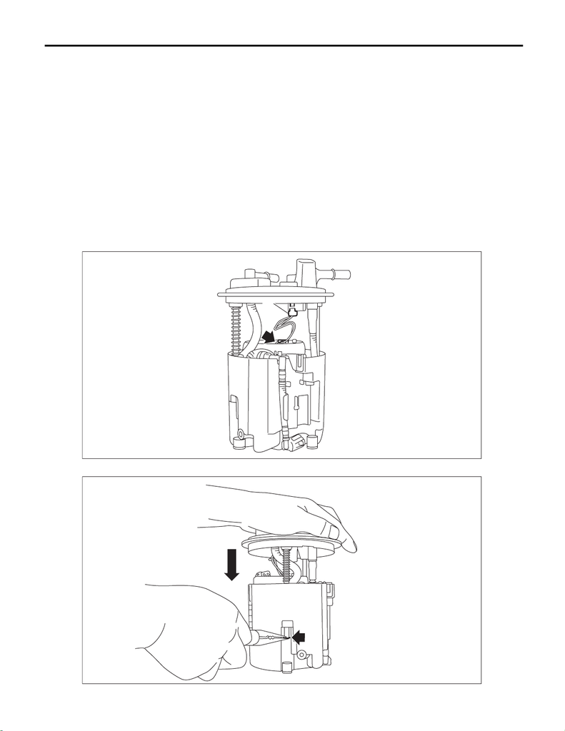

FU(w/o STI)-183

Fuel Filter

FUEL INJECTION (FUEL SYSTEMS)

39.Fuel Filter

A: REMOVAL

WARNING:

Place “NO OPEN FLAMES” signs near the working area.

CAUTION:

• Be careful not to spill fuel.

• If the fuel gauge indicates that two thirds or more of the fuel is remaining, be sure to drain fuel be-

fore starting work to avoid the fuel to spill.

• Be careful not to drop or apply any impact to the fuel pump during work. This may deteriorate its

performance.

NOTE:

The fuel filter is built in fuel pump assembly.

1) Remove the fuel pump assembly. <Ref. to FU(w/o STI)-168, REMOVAL, Fuel Pump.>

2) Remove the fuel level sensor. <Ref. to FU(w/o STI)-173, REMOVAL, Fuel Level Sensor.>

3) Remove the connector cable from the clip, and disconnect the connector (A) of the connector cable.

4) Push the fuel filter assembly in the direction of the arrow to compress, and detach the clip.

(A)

FU-07677

FU-07678

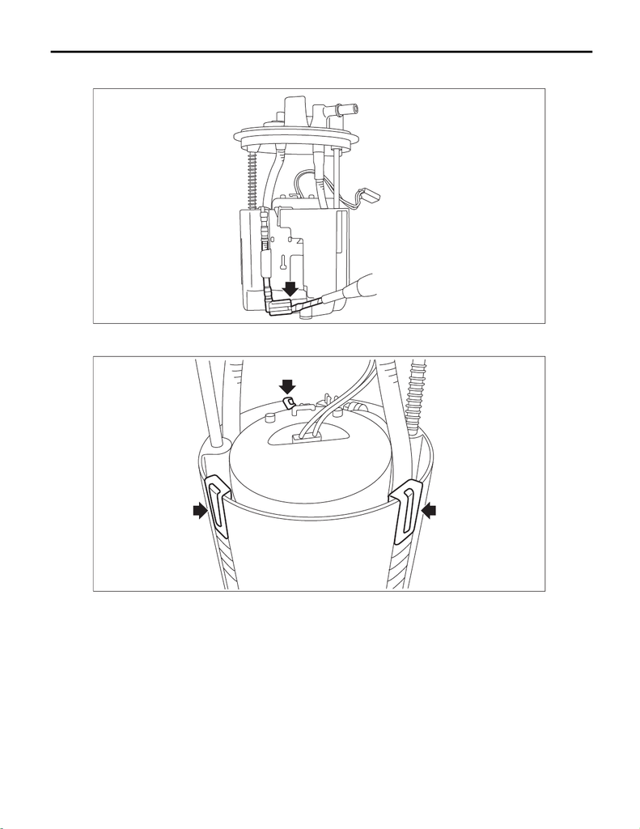

FU(w/o STI)-184

Fuel Filter

FUEL INJECTION (FUEL SYSTEMS)

5) Release the claw of the tube assembly using a flat tip screwdriver or similar tool wrapped with a protection

tape, and remove the tube assembly from the fuel chamber assembly.

6) Release three claws on the fuel pump holder from the fuel chamber assembly, and raise the fuel filter as-

sembly.

FU-08452

FU-07680

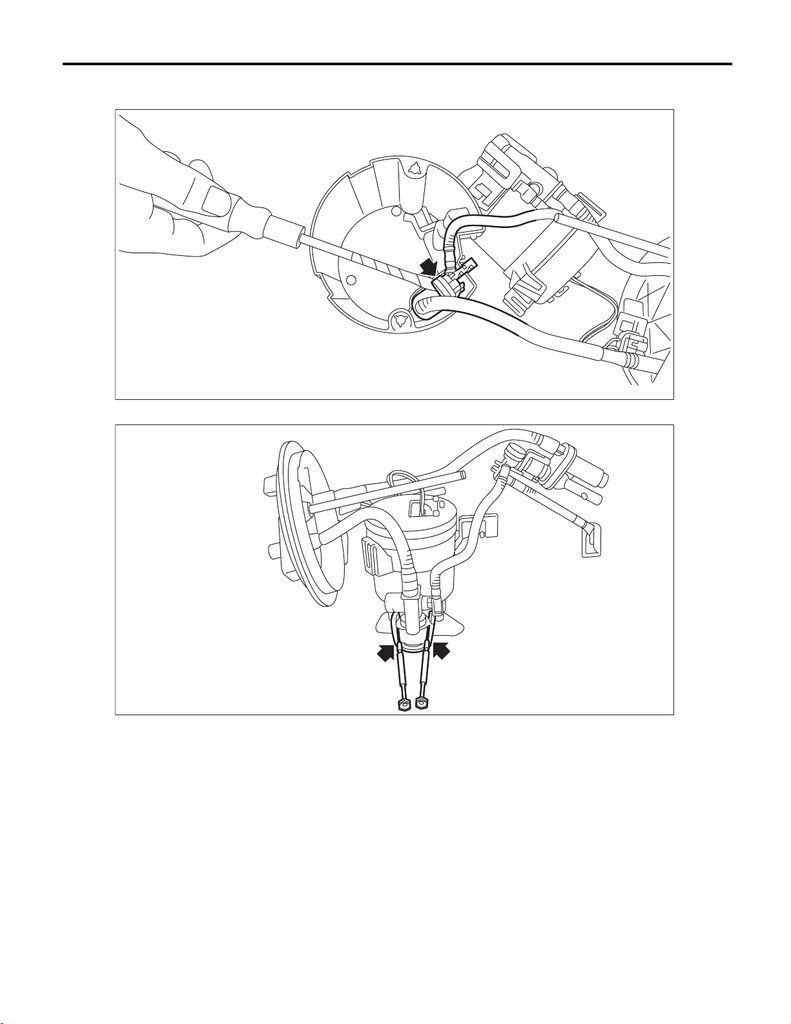

FU(w/o STI)-185

Fuel Filter

FUEL INJECTION (FUEL SYSTEMS)

7) Using a flat tip screwdriver or similar tool wrapped with a protection tape, remove the tube assembly from

the fuel chamber assembly, and separate the fuel filter assembly and fuel chamber assembly.

8) Using a precision driver or similar tool wrapped with a protection tape, expand the claws on the fuel pump.

FU-07681

FU-07682

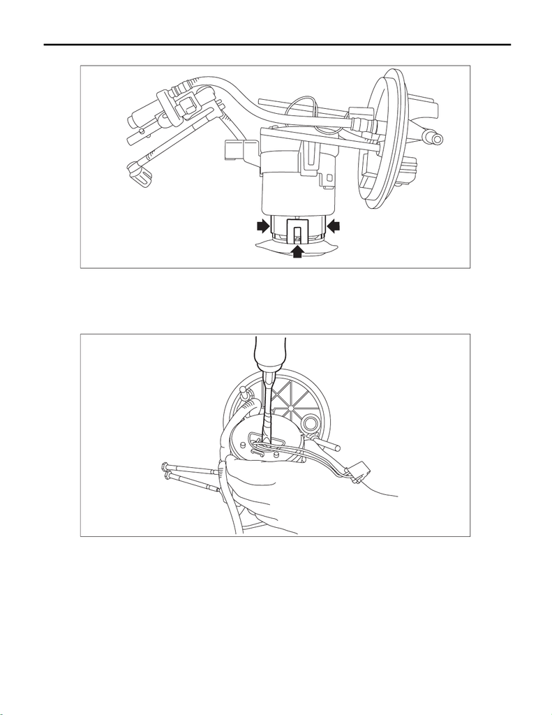

FU(w/o STI)-186

Fuel Filter

FUEL INJECTION (FUEL SYSTEMS)

9) Release the claws on the fuel pump.

10) Using a flat tip screwdriver or similar tool wrapped with a protection tape, press on the fuel pump and re-

move the fuel pump together with the fuel pump holder from the fuel filter assembly.

CAUTION:

If O-rings remain on the fuel filter assembly side, carefully remove them with a precision screwdriver

or similar tool wrapped with a protection tape.

FU-07683

FU-07275

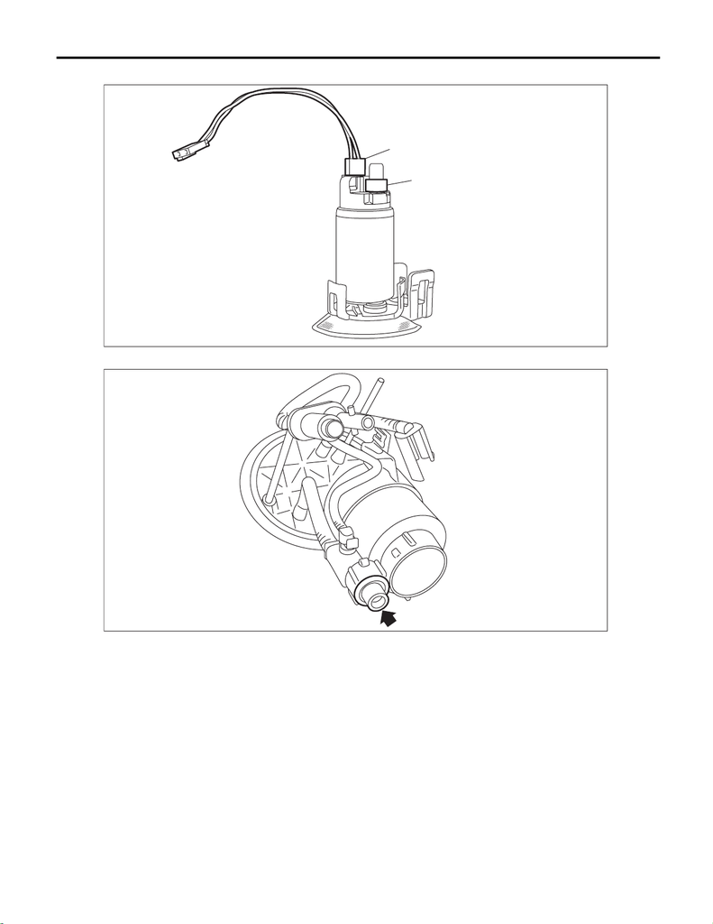

FU(w/o STI)-187

Fuel Filter

FUEL INJECTION (FUEL SYSTEMS)

11) Remove the spacer (A) and connector cable (B) from the fuel pump.

12) Remove the pressure regulator from the fuel filter assembly.

FU-07272

(A)

(B)

FU-07684

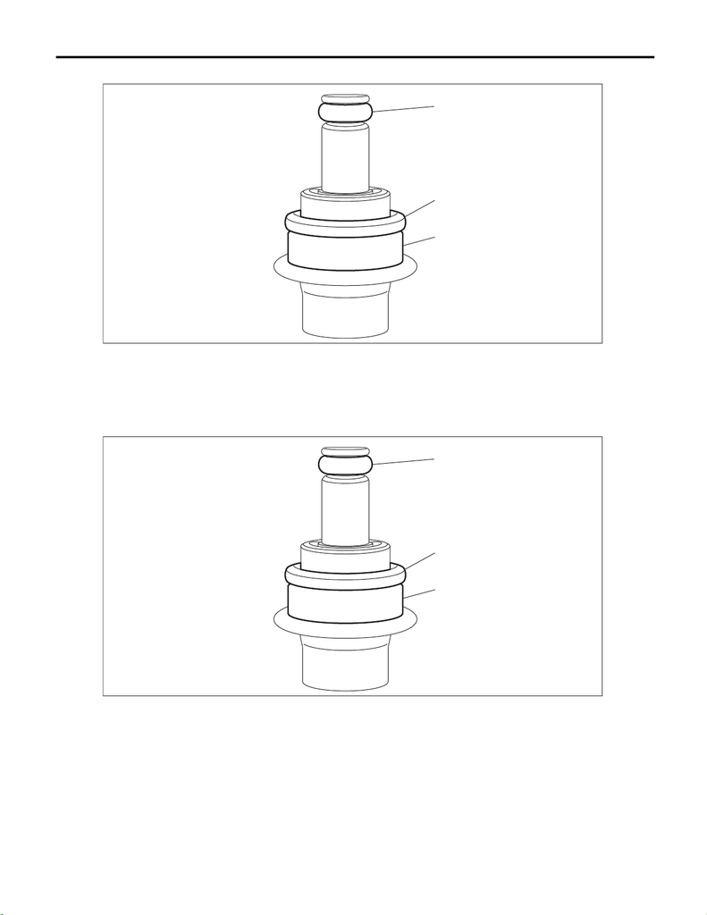

FU(w/o STI)-188

Fuel Filter

FUEL INJECTION (FUEL SYSTEMS)

13) Remove O-ring (A), O-ring (B), and backup ring (C) from the pressure regulator.

B: INSTALLATION

1) Install O-ring (A), O-ring (B), and backup ring (C) to the pressure regulator.

NOTE:

• Use new O-rings.

• Apply gasoline to the O-ring and backup ring.

FU-07274

(A)

(B)

(C)

FU-07274

(A)

(B)

(C)

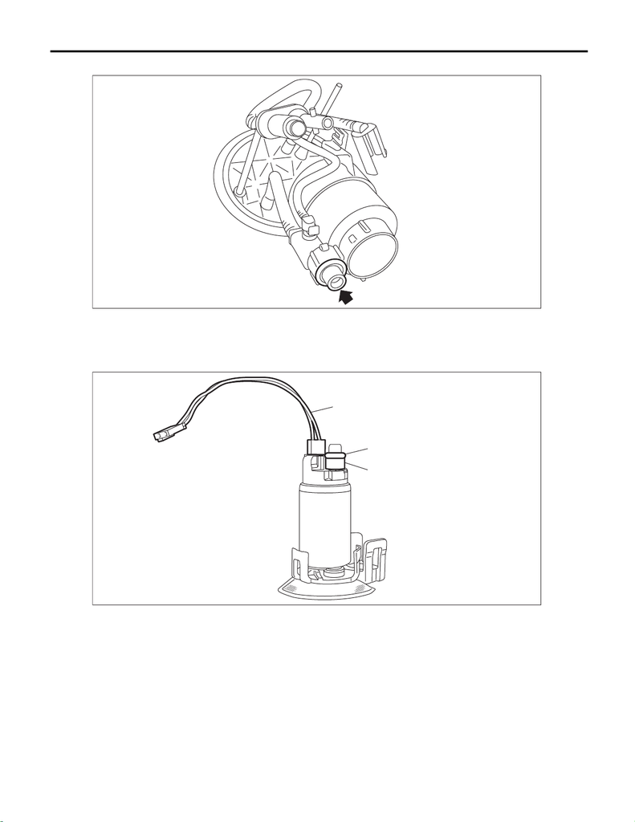

FU(w/o STI)-189

Fuel Filter

FUEL INJECTION (FUEL SYSTEMS)

2) Install the pressure regulator to the fuel filter assembly.

3) Install O-ring (A), spacer (B), and connector cable (C) to the fuel pump.

NOTE:

• Use new O-rings and the connector cable.

• Apply gasoline to the O-rings and the spacer.

FU-07684

FU-07276

(C)

(A)

(B)

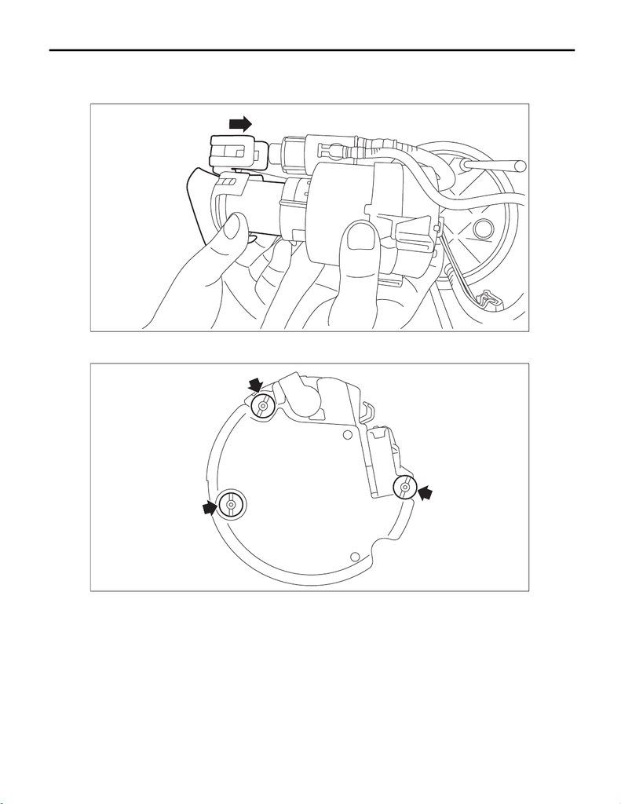

FU(w/o STI)-190

Fuel Filter

FUEL INJECTION (FUEL SYSTEMS)

4) Install the fuel pump to the fuel filter assembly.

5) Check that the cushions of the fuel chamber assembly for dislocation. If any of them is dislocated, install

a new cushion.

FU-07685

FU-07728

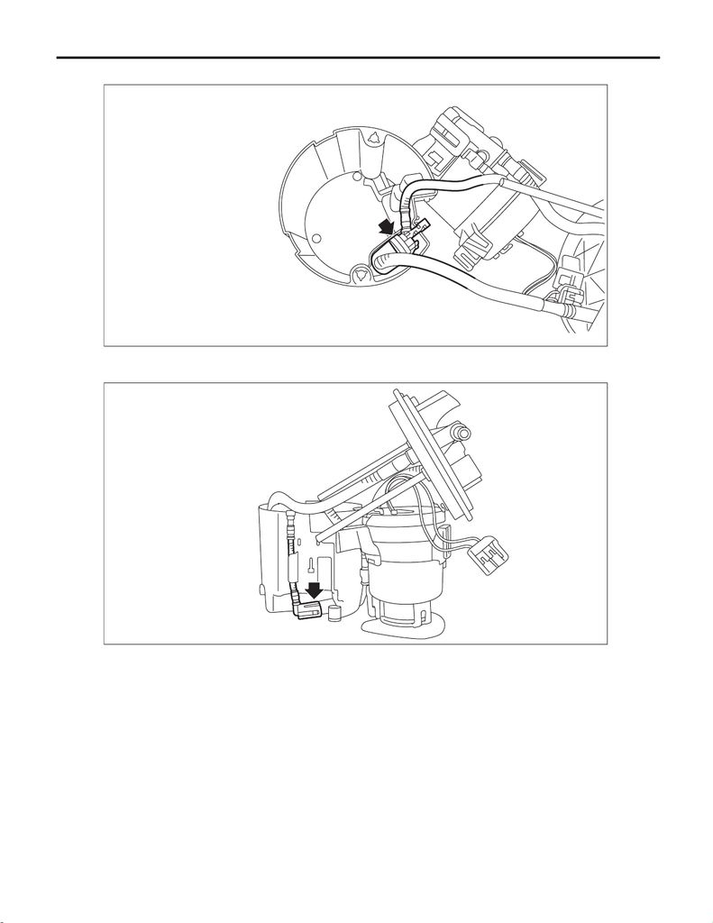

FU(w/o STI)-191

Fuel Filter

FUEL INJECTION (FUEL SYSTEMS)

6) Slowly press in and install the tube assembly to the fuel chamber assembly until a clicking sound is heard.

7) Install the tube assembly to the fuel chamber assembly, and connect the tube assembly to the fuel cham-

ber assembly.

FU-07741

FU-08451

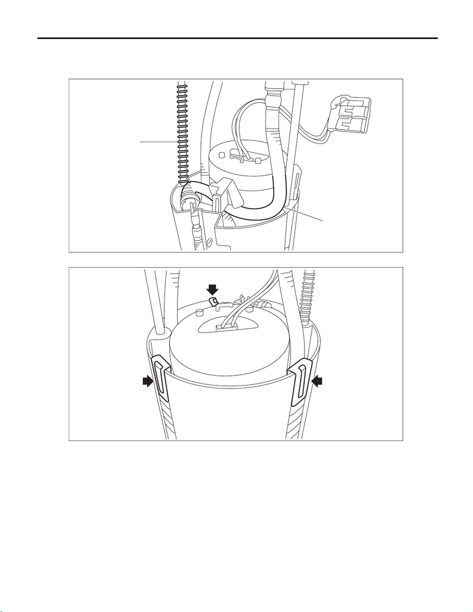

FU(w/o STI)-192

Fuel Filter

FUEL INJECTION (FUEL SYSTEMS)

8) Install the fuel filter assembly to the fuel chamber assembly.

NOTE:

• Set the tube (A) and spring (B) for the fuel filter assembly as shown in the figure.

• Check that the claw connecting the fuel camber assembly and the fuel filter assembly is securely fastened.

(A)

(B)

FU-07687

FU-07680

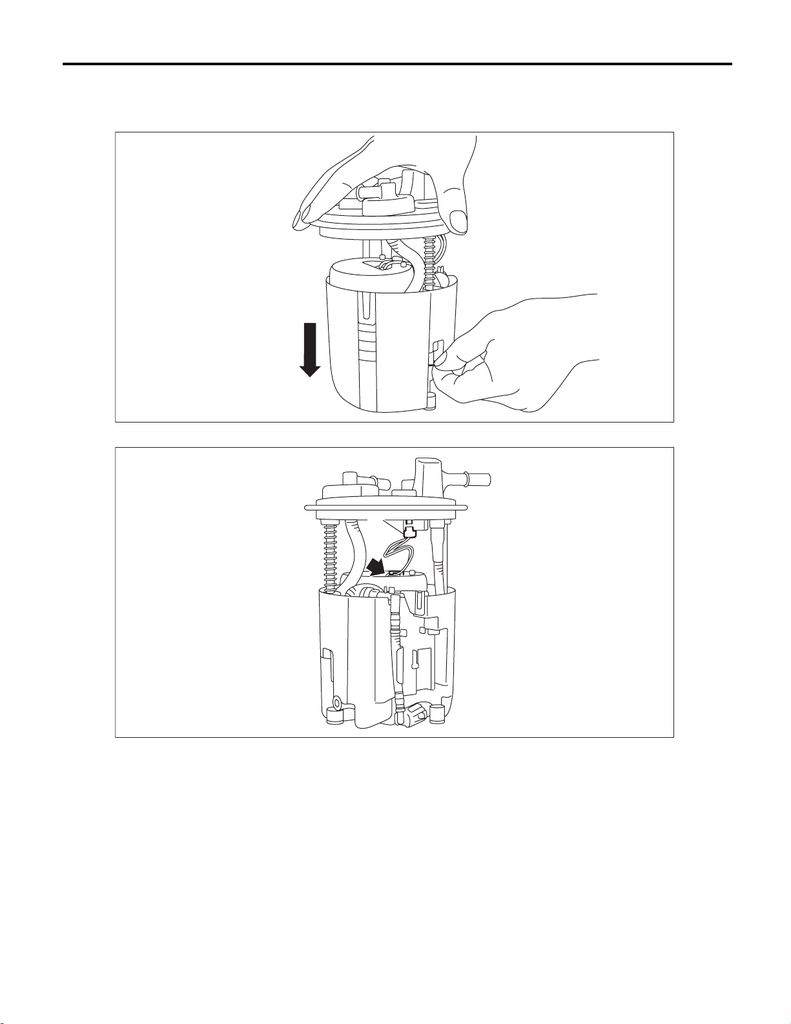

FU(w/o STI)-193

Fuel Filter

FUEL INJECTION (FUEL SYSTEMS)

9) Push the fuel filter assembly in the direction of the arrow to compress, and attach the clip.

NOTE:

Use a new clip.

10) Secure the connector cable with the clip, and connect the connector (A) of the connector cable.

11) Install the fuel level sensor. <Ref. to FU(w/o STI)-174, INSTALLATION, Fuel Level Sensor.>

12) Inspect the fuel level sensor. <Ref. to FU(w/o STI)-175, INSPECTION, Fuel Level Sensor.>

13) Install the fuel pump assembly. <Ref. to FU(w/o STI)-171, INSTALLATION, Fuel Pump.>

FU-07688

(A)

FU-07677